# Audio filters

Audio filtering techniques and applications

signal-processing

audio

filtering

digital-signal-processing

python

scipy

Author

Nipun Batra

Published

June 18, 2021

## Introduction

In this post I will look into some filters for audio processing in ffmpeg, sox, and Python. I have recorded a small 6 second audio clip where for the first couple of seconds I was not speaking, but background noise is present.

I had recorded the audio on my Apple device and it was default recorded in `.m4a` format. I convert it to the `wav` format. I use ffmpeg for the same. In addition, I am using two flags: `-v quiet` to reduce the amount of information printed on the console. Second, I am using `-y` to overwrite an existing file with the same name.

```python
!ffmpeg -i Test.m4a Test.wav -v quiet -y
```

```python
from IPython.display import Audio
import matplotlib.pyplot as plt
%matplotlib inline
```

```python
Audio("Test.wav")
```

[interactive chart not shown]

```python
!ffmpeg -i Test.wav -lavfi showspectrumpic=s=720x540:color='magma' ../images/input-spectogram.png -y -v quiet
```

[figure not shown]

As can be seen in the above image, I am speaking somewhere close to 3.70 seconds onwards. However, the audio is pretty noisy before this even though I am not speaking. This is due to the background noise coming in from the fans and the air conditioning system.

```python
!sox Test.wav -n spectrogram -o ../images/sox-sg.png
```

[figure not shown]

```python
!sox Test.wav -n rate 32k spectrogram  -o ../images/sox-sg-trimmed.png
```

[figure not shown]

```python
!ffmpeg -i Test.wav
```

```
ffmpeg version 4.4 Copyright (c) 2000-2021 the FFmpeg developers

  built with Apple clang version 12.0.5 (clang-1205.0.22.9)

  configuration: --prefix=/usr/local/Cellar/ffmpeg/4.4_2 --enable-shared --enable-pthreads --enable-version3 --cc=clang --host-cflags= --host-ldflags= --enable-ffplay --enable-gnutls --enable-gpl --enable-libaom --enable-libbluray --enable-libdav1d --enable-libmp3lame --enable-libopus --enable-libra…

  libavutil      56. 70.100 / 56. 70.100

  libavcodec     58.134.100 / 58.134.100

  libavformat    58. 76.100 / 58. 76.100

  libavdevice    58. 13.100 / 58. 13.100

  libavfilter     7.110.100 /  7.110.100

  libavresample   4.  0.  0 /  4.  0.  0

  libswscale      5.  9.100 /  5.  9.100

  libswresample   3.  9.100 /  3.  9.100

  libpostproc    55.  9.100 / 55.  9.100

Guessed Channel Layout for Input Stream #0.0 : mono

Input #0, wav, from 'Test.wav':

  Metadata:

    title           : Test

    encoder         : Lavf58.76.100

  Duration: 00:00:06.63, bitrate: 768 kb/s

  Stream #0:0: Audio: pcm_s16le ([1][0][0][0] / 0x0001), 48000 Hz, mono, s16, 768 kb/s

At least one output file must be specified
```

As can be seen from the cell above, the recording rate is 48 kHz. We will need this when we do some processing in Python.

```python
!ffmpeg -i Test.wav -ss 0 -to 3.5 -c copy Noise-Test.wav -v quiet -y
```

```python
Audio('Noise-Test.wav')
```

[interactive chart not shown]

```python
!sox Noise-Test.wav -n rate 32k spectrogram  -o ../images/sox-noise.png
```

[figure not shown]

```python
!sox Noise-Test.wav -n noiseprof noise.prof
```

```python
!sox Noise-Test.wav Noise-Test-cleaned.wav noisered noise.prof 0.21
```

```python
Audio("Noise-Test-cleaned.wav")
```

[interactive chart not shown]

```python
!sox Test.wav Test-cleaned-05.wav noisered noise.prof 0.05


!sox Test.wav Test-cleaned-18.wav noisered noise.prof 0.18
!sox Test.wav Test-cleaned-21.wav noisered noise.prof 0.21
```

```python
Audio("Test-cleaned-05.wav")
```

[interactive chart not shown]

```python
Audio("Test-cleaned-18.wav")
```

[interactive chart not shown]

```python
Audio("Test-cleaned-21.wav")
```

[output not shown]

```python
!sox Test-cleaned-21.wav -n rate 32k spectrogram  -o ../images/sox-cleaned-21.png
```

[figure not shown]

```python
!sox Test-cleaned-05.wav -n rate 32k spectrogram  -o ../images/sox-cleaned-05.png
```

[figure not shown]

```python
Audio("Test-audacity.wav")
```

[interactive chart not shown]

```python
!sox Test-audacity.wav -n rate 32k spectrogram  -o ../images/sg-audacity.png
```

[figure not shown]

```python
!ffmpeg -i Test.wav -filter:a "highpass=f=300" high-passed.wav -y -v quiet
```

```python
Audio("high-passed.wav")
```

[interactive chart not shown]

```python
!sox high-passed.wav -n rate 32k spectrogram  -o ../images/highpass.png
```

[figure not shown]

```python
Audio("test-imovie.wav")
```

[interactive chart not shown]

```python
!sox test-imovie.wav -n remix 1 rate 32k spectrogram  -o ../images/imovie.png
```

Original

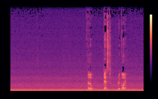

Audacity

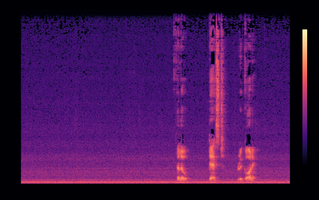

Sox:0.21

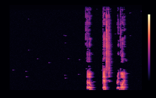

Sox:0.05

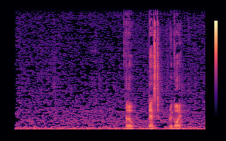

HPF:300

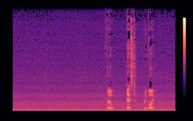

imovie

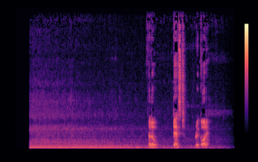

```python
import mediapy

orig  = mediapy.read_image('../images/sox-sg-trimmed.png')
audacity = mediapy.read_image('../images/sg-audacity.png')
sox_21 = mediapy.read_image('../images/sox-cleaned-21.png')
sox_05 = mediapy.read_image('../images/sox-cleaned-05.png')
high_pass_300 = mediapy.read_image('../images/highpass.png')
imovie = mediapy.read_image('../images/imovie.png')




mediapy.show_images({'Original':orig,
                     'Audacity':audacity,
                     'Sox:0.21':sox_21,
                    'Sox:0.05':sox_05,
                    'HPF:300': high_pass_300,
                    'imovie':imovie},
                    cmap='magma', columns=4, height=200 )
```

```python
!sox test-audacity.wav output.dat
```

```python
import pandas as pd
df = pd.read_csv("output.dat", skiprows=2, index_col=0, names=['values'],delim_whitespace=True)
df = df.astype('float64')
```

```python
df.plot()
```

[figure not shown]